# Early warning signals for critical transitions in mood

A simulation study, a reproduction, and a design recommendation

Author

Abhay Mettu

Published

July 26, 2026

**NoteReproducibility**

Every number in this report is computed from the scripts in `sim/` and `analysis/`, run in order from a clean clone. Global seed `20260726`. The dataset is fetched from OSF by `analysis/00_download.R` and pinned by SHA-256; it is not redistributed here.

Data: Kossakowski, J. J., Groot, P. C., Haslbeck, J. M. B., Borsboom, D., & Wichers, M. (2017). Data from ‘Critical Slowing Down as a Personalized Early Warning Signal for Depression’. *Journal of Open Psychology Data*, 5: 1. doi:10.5334/jopd.29. CC-BY 4.0.

# 1 Motivation

Mood may behave as a dynamical system with alternative stable states. If it does, then before a transition into depression the system should show *critical slowing down*: as the basin of attraction flattens, recovery from perturbation slows, and the observable signature is rising autocorrelation and rising variance (Leemput et al. 2014; Wichers et al. 2016).

The published critique is that between-subject evidence cannot establish a within-person phenomenon (Bos and De Jonge 2014), a point the original authors conceded. Whether intraindividual early warning signals anticipate intraindividual transitions remains open. It is, at bottom, a time-series question about short, noisy, unevenly-spaced series — which is where this project sits.

Two things should be read before the results. Section 10 places this work against the existing literature — the central objection tested here was raised and answered once already, and a 2024 review reaches this report’s overall conclusion independently. Section 7 records the four design errors made along the way, three of which would have produced a wrong result.

This report is organised around one discipline: **no detector was ever tuned against the real data.** Phase 0 validates the machinery on simulated data with a planted transition and known ground truth. Only then is the real dataset downloaded.

# 2 What critical slowing down predicts

The model is the normal form of a fold bifurcation,

$$dx = \left(-x^3 + x + c(t)\right)dt + \sigma_p\,dW,$$

with $x$ a latent mood valence and $c$ a slow control parameter. Two stable branches exist for $|c| < 2/(3\sqrt3) = 0.385$; lowering $c$ past $-0.385$ destroys the euthymic branch and the system drops into the depressed one.

Critical slowing down is *derived*, not assumed. The local recovery rate at a stable point is $\lambda = -3x^{*2} + 1$, and on the euthymic branch $x^* \to 1/\sqrt3$ as the fold is approached, so $\lambda \to 0$. The linearised process is Ornstein–Uhlenbeck, giving

$$\text{AR}(1)\ \text{over gap } \Delta = e^{\lambda\Delta} \to 1,
\qquad \text{Var} = \frac{\sigma_p^2}{2|\lambda|} \to \infty.$$

That derivation is also the yardstick: the detectors must recover it on clean data or they are broken.

One model time unit is calibrated to 5 hours, so that far from the bifurcation the lag-1 autocorrelation at 90-minute spacing is ≈ 0.4, a typical ESM “emotional inertia” value. **Every statement about days of data depends on this anchor**, and it is not swept (`DECISIONS.md` D3).

# 3 Simulation validation

## 3.1 The gate

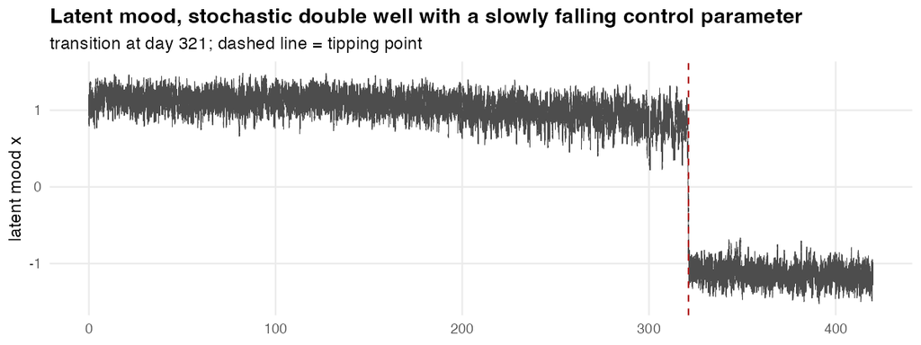

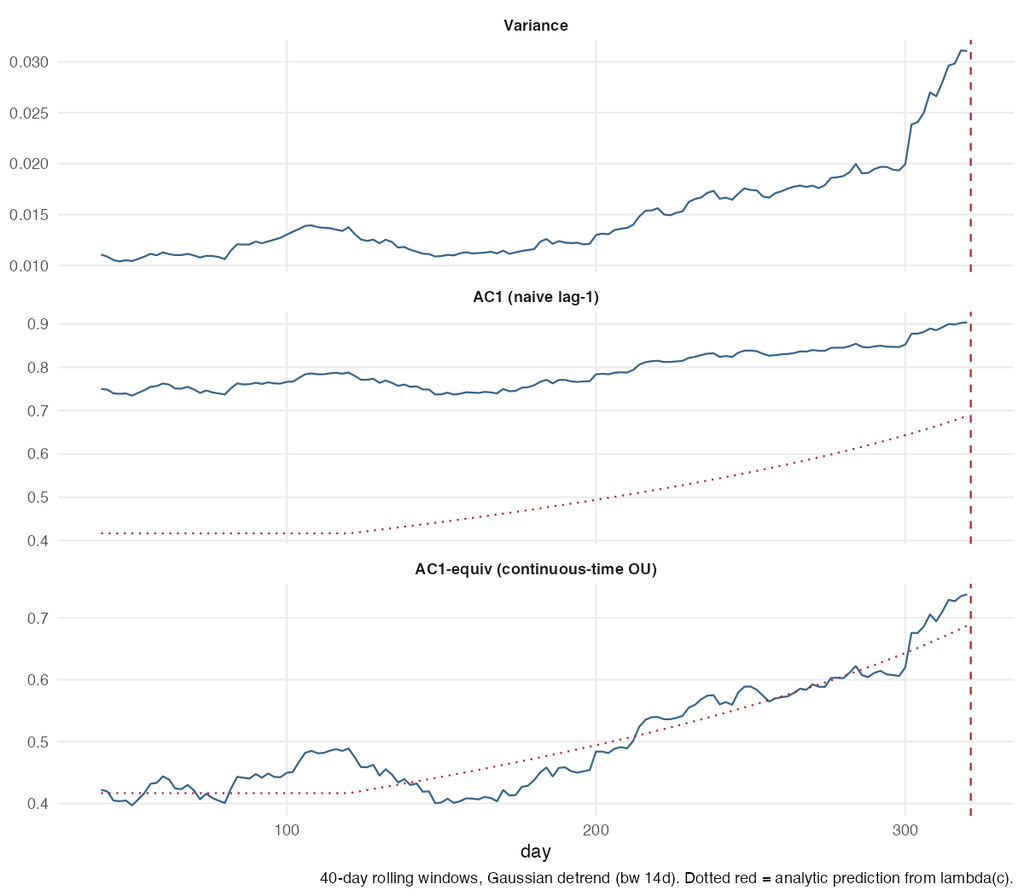

On dense, noise-free data the indicators rise ahead of the transition with Kendall’s $\tau \approx 0.70$, and the empirical rolling AC1 tracks the analytic $\lambda(c)$. On a non-tipping null the same machinery gives $\tau \approx 0.02$. Euler–Maruyama step size was verified rather than assumed.

## 3.2 The trend test is anticonservative by a factor of six

Rolling windows overlap by ~93%, so the Kendall tau computed on the indicator series is heavily autocorrelated and its nominal p-value is meaningless.

| window (days) | indicator | nominal 5% critical tau | actual 5% point of null | true size of a nominal 5% test |
| --- | --- | --- | --- | --- |
| 20 | ac1_naive | 0.124 | 0.363 | 28% |
| 30 | ac1_naive | 0.129 | 0.466 | 34% |
| 45 | ac1_naive | 0.136 | 0.566 | 40% |
| 60 | ac1_naive | 0.144 | 0.641 | 42% |
| 20 | ac1_ou | 0.124 | 0.383 | 30% |
| 30 | ac1_ou | 0.129 | 0.477 | 33% |
| 45 | ac1_ou | 0.136 | 0.565 | 40% |
| 60 | ac1_ou | 0.144 | 0.649 | 43% |
| 20 | variance | 0.124 | 0.369 | 31% |
| 30 | variance | 0.129 | 0.454 | 36% |
| 45 | variance | 0.136 | 0.536 | 39% |
| 60 | variance | 0.144 | 0.672 | 39% |

**A nominally 5% test rejects 28–43% of the time under the null.** Every threshold in this project is calibrated by simulation or by surrogate data; nominal p-values are used nowhere.

## 3.3 Measurement error biases toward the hypothesis

An AR(1) observed with additive white noise is an ARMA(1,1), so the naive lag-1 autocorrelation is attenuated by the reliability ratio $s^2/(s^2+\sigma_m^2)$. Because $s^2$ grows on the approach to the fold, **the attenuation shrinks along the approach**, and the measured autocorrelation rises partly for a reason unrelated to slowing down.

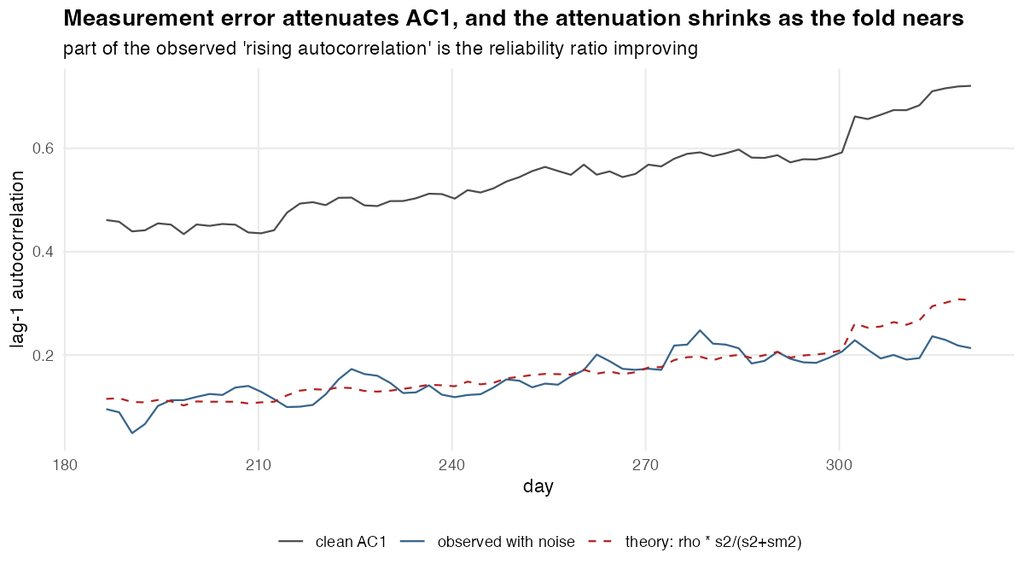

## 3.4 The response scale can invent the signal, or reverse it

The largest finding in Phase 0, and it was found by chasing an anomaly: the clinical null showed a *negative* variance trend where the latent variance genuinely rises ~14%.

The variance of a rounded variable depends on where its mean sits between two category boundaries. Approaching a transition the latent mean *slides*, so it moves relative to the boundaries and drags rounding variance with it.

Identical dynamics throughout. Only the response scale changes.

| response model | tau on the null (truth: mildly positive) | AUC |
| --- | --- | --- |
| continuous | 0.293 | 0.780 |
| Likert-11, centred | -0.633 | 0.758 |
| Likert-7, at ceiling | -0.329 | 0.947 |
| Likert-7, centred | 0.518 | 0.925 |

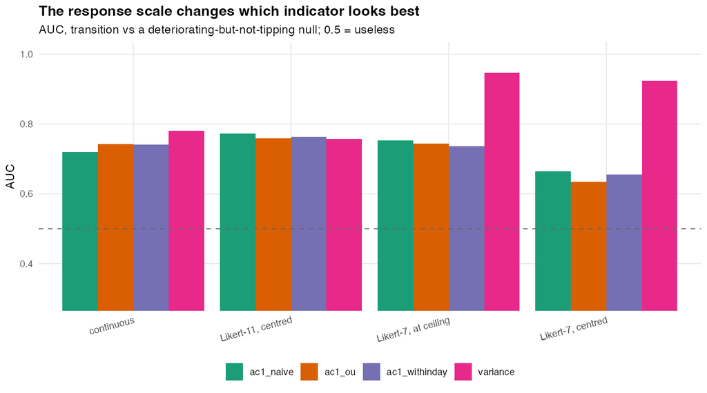

## 3.5 Modelling measurement error correctly does not help

Parameter recovery on a stationary OU at the real ESM sampling grid. True lambda = 0.6 per hour.

| sigma_m | naive AC1 | lambda, fit_ou | lambda, fit_ou_me | sigma_m recovered |
| --- | --- | --- | --- | --- |
| 0.1 | 0.344 | 0.775 | 0.619 | 0.080 |
| 0.4 | 0.097 | 3.362 | 1.129 | 0.324 |
| 0.8 | 0.026 | 12.448 | 3.699 | 0.677 |

`fit_ou` is catastrophic at realistic noise, returning $\lambda$ twenty times too large: it reads white measurement noise as ultra-fast mean reversion. The state-space version recovers both parameters far better — **and still loses on discrimination at every noise level** (AUC 0.72 / 0.62 / 0.55 against 0.91 / 0.71 / 0.65 for `ac1_ou`). On ~450-observation windows a four-parameter Kalman fit has enough sampling variance that the indicator series is mostly noise. Removing the bias cost more variance than the bias was worth.

## 3.6 Power

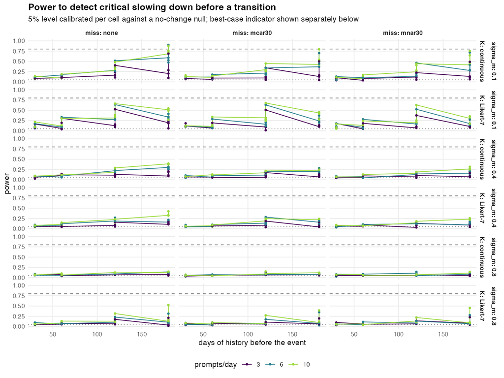

Mean power over the rest of the 216-cell grid.

| lever | level | power |
| --- | --- | --- |
| days | 30 | 0.075 |
| days | 60 | 0.094 |
| days | 120 | 0.177 |
| days | 180 | 0.227 |
| ppd | 3 | 0.101 |
| ppd | 6 | 0.148 |
| ppd | 10 | 0.183 |
| miss | mcar30 | 0.139 |
| miss | mnar30 | 0.128 |
| miss | none | 0.168 |
| sigma_m | 0.1 | 0.223 |
| sigma_m | 0.4 | 0.127 |
| sigma_m | 0.8 | 0.087 |

# 4 Reproduction

The dataset is a single participant with a history of major depressive disorder: 1471 beeps over 239 days, ~10 prompts/day protocol at 62% realised compliance, including a double-blind antidepressant taper.

## 4.1 The transition is an interpretation

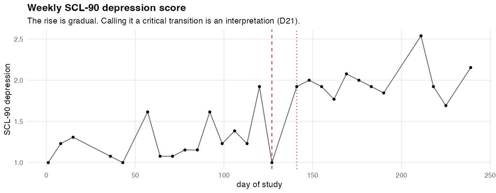

The weekly SCL-90 depression score does not jump. It sits at 1.0–1.6 through phases 1–3 and rises through phase 4 to a sustained 1.8–2.5. A least-squares changepoint puts the transition at **day 127**; the first sustained crossing of baseline mean + 2 SD puts it at **day 141**. Both are carried forward.

## 4.2 Nominal significance versus a surrogate null

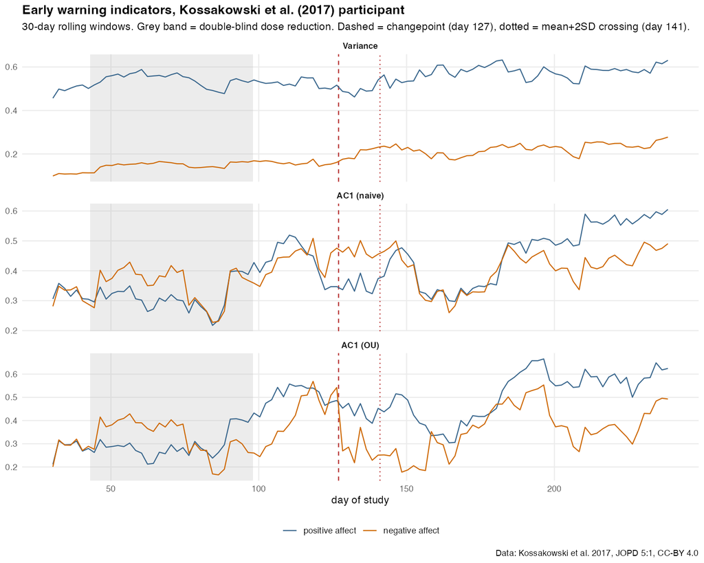

Pre-transition window. Same data, two nulls.

| series | transition | indicator | tau | p (block bootstrap) | p (nominal) |
| --- | --- | --- | --- | --- | --- |
| pa | changepoint | variance | -0.104 | 0.610 | 0.85351302 |
| pa | changepoint | ac1_naive | 0.274 | 0.246 | 0.00275511 |
| pa | changepoint | ac1_withinday | 0.381 | 0.182 | 0.00005630 |
| pa | changepoint | ac1_ou | 0.469 | 0.085 | 0.00000098 |
| na_ | changepoint | variance | 0.413 | 0.134 | 0.00001399 |
| na_ | changepoint | ac1_naive | 0.376 | 0.171 | 0.00006949 |
| na_ | changepoint | ac1_withinday | 0.211 | 0.332 | 0.01626977 |
| na_ | changepoint | ac1_ou | 0.177 | 0.276 | 0.03649239 |
| pa | crossing | variance | -0.227 | 0.742 | 0.99331273 |
| pa | crossing | ac1_naive | 0.236 | 0.257 | 0.00504714 |
| pa | crossing | ac1_withinday | 0.208 | 0.286 | 0.01186072 |
| pa | crossing | ac1_ou | 0.447 | 0.074 | 0.00000058 |
| na_ | crossing | variance | 0.558 | 0.037 | 0.00000000 |
| na_ | crossing | ac1_naive | 0.458 | 0.092 | 0.00000030 |
| na_ | crossing | ac1_withinday | 0.165 | 0.320 | 0.03631459 |
| na_ | crossing | ac1_ou | 0.003 | 0.448 | 0.48872335 |

**13 of 16 tests are significant with nominal p-values. 1 of 16 survive a moving-block bootstrap** that preserves the local dynamics but destroys the trend. The one survivor is one test among sixteen with no multiplicity correction.

## 4.3 An out-of-sample prediction, and the test that was needed to use it

Section 3.4 predicted, in simulation and before this dataset was downloaded, that the variance indicator is confounded by an item’s position on its response scale. In this participant:

Variance indicator by item, pre-transition.

| item | categories to nearest bound | tau | p (bootstrap) |
| --- | --- | --- | --- |
| mood_suspic | 0.263 | 0.633 | 0.026 |
| mood_doubt | 0.851 | 0.468 | 0.123 |
| mood_irritat | 1.241 | 0.769 | 0.005 |
| mood_satisfi | 2.797 | 0.134 | 0.354 |
| mood_down | 2.822 | 0.116 | 0.425 |
| mood_relaxed | 2.827 | 0.002 | 0.529 |
| mood_enthus | 2.833 | -0.439 | 0.870 |
| mood_anxious | 2.911 | -0.180 | 0.683 |
| mood_cheerf | 2.913 | 0.026 | 0.509 |
| mood_guilty | 2.990 | 0.354 | 0.176 |
| mood_lonely | 2.993 | -0.374 | 0.824 |
| mood_strong | 2.997 | -0.303 | 0.785 |

Mean $\tau$ is **+0.62 for items within 1.5 categories of their floor** and **−0.07 for mid-scale items**. The autocorrelation indicators show no such split.

But the three floored items are symptom items, floored *because the person is not yet symptomatic*. Genuine symptom emergence predicts the same correlation. So: generate a synthetic series following each item’s observed mean trajectory with **constant latent variance** — no slowing down at all — round it to the item’s scale, and run the identical pipeline.

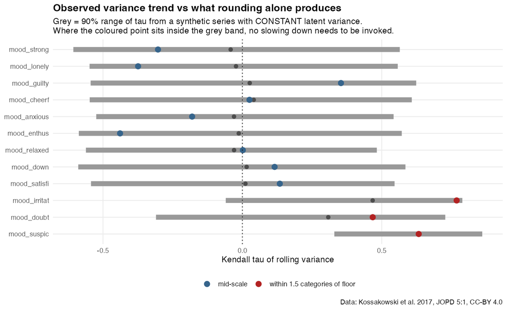

A constant-variance synthetic reproduces most of the observed trend.

| group | n | observed tau | artefact-only tau |
| --- | --- | --- | --- |
| within 1.5 categories of floor | 3 | 0.623 | 0.469 |
| mid-scale | 9 | -0.074 | -0.005 |

The artefact-only series reproduces **75% of the observed variance trend** in the floored items, and for **12 of 12 items** the observed trend is not beyond what rounding alone produces.

**Important**

The variance early-warning signal in this dataset carries no demonstrable information beyond the item mean — and the item mean is the symptom. An early warning that is a function of current symptom level is not an early warning.

# 5 Robustness

Preregistered in `preregistration/PREREG_phase2_phase3.md`, committed before any Phase 2 code existed. 5760 specifications; none failed to compute.

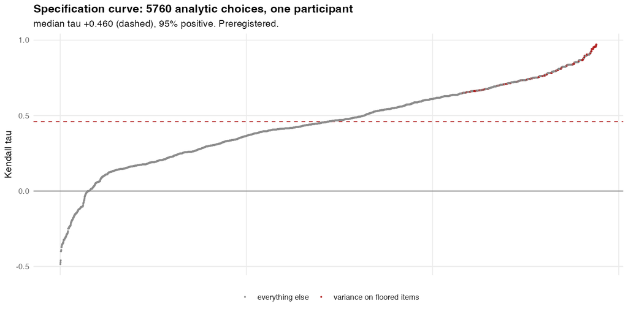

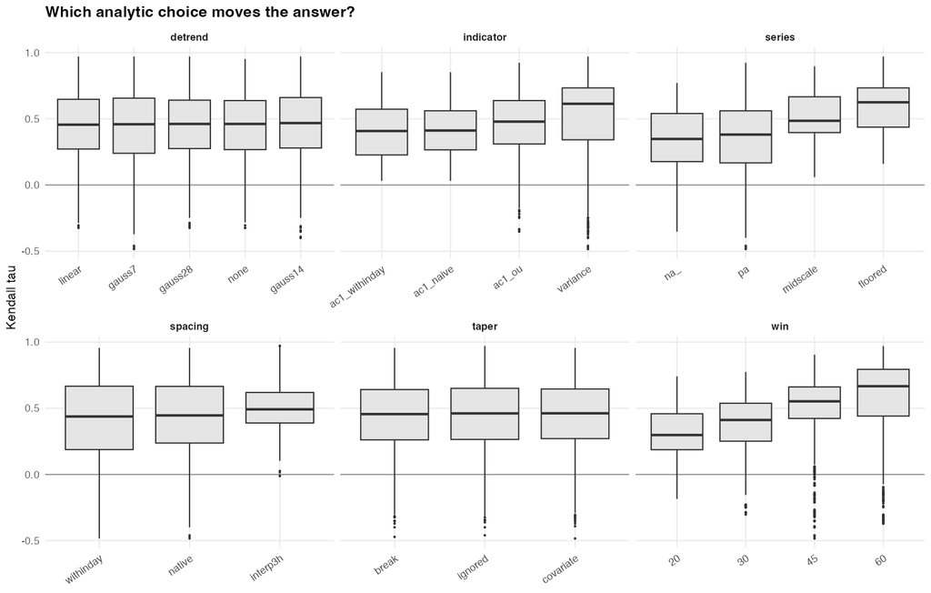

Registered joint test. Observed S1 = +0.460, S2 = 0.947. 100 surrogate curves per block length, entire curve recomputed each time.

| block_n | S1_null_med | S1_null_q95 | S2_null_med | S2_null_q95 | p_S1 | p_S2 |
| --- | --- | --- | --- | --- | --- | --- |
| 6 | 0.056 | 0.196 | 0.548 | 0.683 | 0.01 | 0.01 |
| 18 | 0.054 | 0.189 | 0.547 | 0.668 | 0.01 | 0.01 |

## 5.1 Registered predictions: three of four falsified

[output not shown]

Reported as they came out. Three of four were wrong, and the way they were wrong is the interesting part.

**The curve is robustly positive.** Median $\tau$ = 0.460, 95% of specifications positive, and no dimension — not one — flips the sign of the median. This is the opposite of the fragility result I expected, and it must be reported as such.

**But window width dominates everything.** Median $\tau$ runs from 0.298 at 20-day windows to 0.667 at 60-day windows, a range of 0.369, while detrending moves it by 0.012 — a factor of about thirty. Wider windows mean fewer, more overlapping windows and a smoother indicator series, which inflates $|\tau|$ mechanically. The single largest analyst degree of freedom is the one with the least substantive content.

**WarningWhat the joint test does and does not license**

A moving-block bootstrap destroys *all* slow temporal structure. Beating it establishes that slow structure exists in these series — which is not in doubt, since the participant became depressed. It does **not** establish that the structure is critical slowing down. Combined with Section 4, where the variance component proved indistinguishable from a rounding artefact, the honest reading is: the curve is consistently positive, and what it is detecting is not established to be the phenomenon of interest.

# 6 Design recommendations

Registered rule, fixed in advance: a configuration is *usable* only if power $\ge$ 0.80 **and** false alarm rate $\le$ 0.10.

## 6.1 Translating into what a clinician faces

Power and false-alarm rate are per-assessment quantities. Nobody experiences per-assessment quantities. A $D$-day monitoring window gives $365/D$ non-overlapping assessments per patient-year, and what decides deployability is the share of raised alarms that are real.

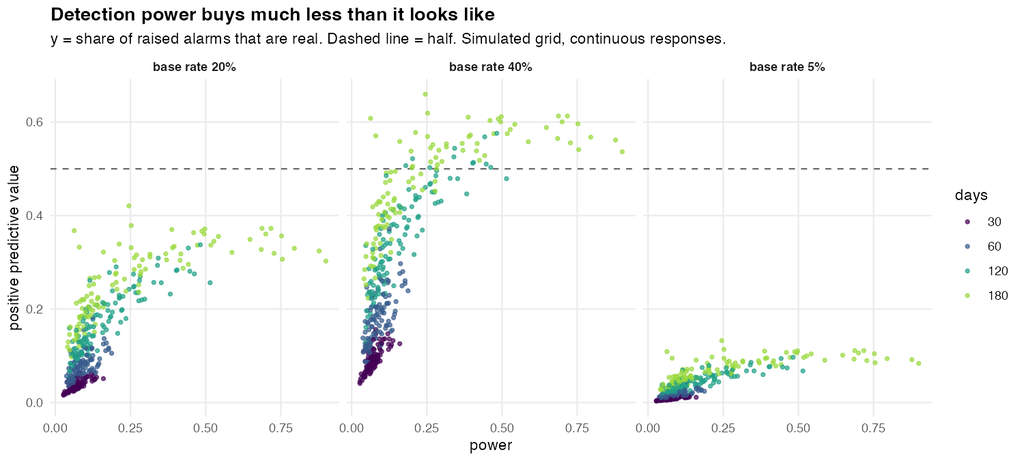

Best-power configurations in deployment units. PPV = share of alarms that are real, at three base rates of a genuine transition.

| response | days | prompts/day | missing | sigma_m | power | false alarm rate | false alarms /100 patient-yrs | PPV at 5% | PPV at 20% | PPV at 40% |
| --- | --- | --- | --- | --- | --- | --- | --- | --- | --- | --- |
| continuous | 180 | 6 | none | 0.1 | 0.900 | 0.302 | 61.340 | 0.084 | 0.303 | 0.537 |
| continuous | 180 | 10 | none | 0.1 | 0.877 | 0.260 | 52.722 | 0.092 | 0.324 | 0.561 |
| continuous | 180 | 10 | mcar30 | 0.1 | 0.795 | 0.225 | 45.625 | 0.094 | 0.330 | 0.568 |
| continuous | 180 | 10 | none | 0.1 | 0.755 | 0.240 | 48.667 | 0.085 | 0.307 | 0.541 |
| continuous | 180 | 10 | mnar30 | 0.1 | 0.752 | 0.185 | 37.514 | 0.104 | 0.357 | 0.596 |
| continuous | 180 | 10 | none | 0.1 | 0.728 | 0.215 | 43.597 | 0.090 | 0.319 | 0.556 |

The best configuration in the entire grid — 180 days, 6 prompts/day, continuous responses, lowest measurement noise — reaches power 0.90 and produces **61 false alarms per 100 patient-years**. Of every 100 alarms it raises, **8 are real** in a general population, **54** even among remitted MDD patients tapering medication — the reproduction participant’s own situation, and the most favourable base rate considered.

## 6.2 What to do if you are designing an ESM study anyway

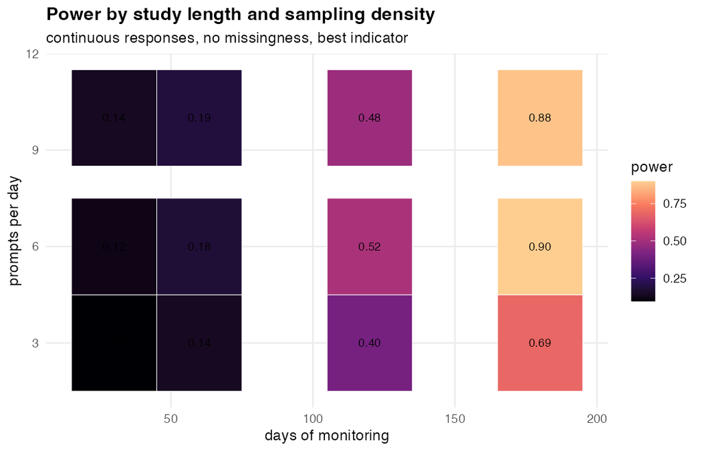

# 7 Errors made, and what they would have cost

Four design errors were made and caught during this project. They are recorded here rather than in a commit log because **three of the four would have produced a wrong result that looked entirely publishable**, and because they are instances of exactly the fragility this project documents. A reader is entitled to know how close the reported numbers came to being different ones.

Each was caught by an internal consistency check, not by inspection. That is the argument for building the checks.

## 7.1 The clinical null tipped 100% of the time

The first non-transitioning null was constructed to sit just short of the fold, on the reasoning that a person who deteriorates without becoming ill is the hard case. Every single run tipped.

The cause is not a coding bug but a property of the system: at $c = -0.235$ the Kramers escape rate is 0.15 per time unit, so a system parked near a fold escapes by noise with near-certainty over a study-length horizon. **“Deteriorating but stable just short of transition” is not a state that exists**, and the null had to be moved to $c = -0.035$, calibrated to zero tips in 120 runs.

*Cost if uncaught:* every false-alarm rate in Section 6 would have been computed against a null that was actually a transition. The headline deployment numbers would have been meaningless. **Caught by an assertion that counted how many nulls tipped.**

## 7.2 Long windows were silently conditioned on the easiest cases

The analysis window is the $D$ days ending at the transition. Without a hold phase before the control-parameter ramp, a 180-day window could only be cut from paths that happened to tip after day 180 — about 70% of them. Those are not a random 70%: they are the paths where noise did *not* tip the system early, which means they travelled further along the ramp and slowed down more. The 30-day cells had no such restriction.

*Cost if uncaught:* “longer series detect better” — the central deliverable of Phase 0 and the basis of the duration-over-density recommendation — would have been part real and part an artefact of conditioning the long cells on the easiest paths. **Caught by asking what fraction of paths each cell was actually using.** A 120-day hold was added; the earliest transition across 200 paths is now day 244, so no conditioning occurs at any length.

## 7.3 “Ceiling effects are mild by construction”

This was written into the decisions log as a justification for not sweeping the response scale. It was wrong, and the thing it dismissed became the largest finding in the project (Section 3.4, Section 4).

*Cost if uncaught:* Phase 0 would have concluded that variance is the strongest indicator — it had the highest mean power in the grid — and Phase 3 would have recommended it. The reproduction would then have found a variance signal in the real data and called it critical slowing down. **Caught by chasing an anomaly: the clinical null showed a negative variance trend where theory says the latent variance rises.** Chasing that one implausible sign is what produced the artefact result.

## 7.4 A single-path comparison that reversed itself

The degradation study (Section 3) initially reported Kendall’s $\tau$ for each layer of realism from one simulated trajectory. On that path, adding 30% missingness *improved* detection relative to the layer below it — a result that is not merely surprising but backwards.

Averaged over 103 paths the ordering is monotone and missingness degrades detection as expected. The between-path SD of $\tau$ is ≈ 0.33, larger than most of the layer effects being compared, so single-trajectory orderings reverse routinely.

*Cost if uncaught:* the report would have claimed that missing data helps. **Caught by re-running the comparison across paths before believing it.** This is a small, self-inflicted instance of the Bos & De Jonge (2014) problem — a single realisation cannot establish a pattern — encountered in simulation, where ground truth was available to settle it.

## 7.5 Engineering failures

Three, none of which changed a reported number, all of which could have:

- A `;`-chained pipeline continued past a crash in the power-grid script. The script had already written its tables, so the results were intact and only figures were lost — but the chain also appended a success marker to the log of the step that failed. `run_all.sh` now uses `set -euo pipefail`.
- Piping a script through `head` sent SIGPIPE and killed it before its final `saveRDS`. This surfaced only when the report failed to find the file. If the file had existed from an earlier run, the report would have silently used stale numbers.
- The expensive simulation grid was not cached, so a plotting bug meant re-running 30 minutes of computation. It is now cached with a guard that re-simulates if the grid definition changes.

## 7.6 What this section is evidence for

Three of four scientific errors pointed in the same direction: **toward finding critical slowing down**. That is not coincidence. An analysis with this many defensible choices has many more ways to manufacture a positive result than a negative one, and the errors that survive review are disproportionately the ones whose output looks like the hypothesis.

That is the same asymmetry documented in Section 3 for the trend test, the measurement-error bias, and the discretisation artefact. The difference is only that those three are properties of the method and these four were mine.

# 8 Limitations

**This is N = 1.** One person, one transition, one taper. A single transition in a single individual cannot establish generality — that is precisely the Bos & De Jonge (2014) critique, and nothing here escapes it. Every Phase 1 and Phase 2 result describes *this participant*, and the reproduction should be read as a case study, not as evidence about a population.

**The simulation is a caricature, not a validated model of mood.** The cubic double-well is the normal form of a fold bifurcation, so it is generic *near a fold* — but assuming mood has a fold assumes the conclusion of the substantive debate. Phase 0 answers “if mood were like this, could we detect it”, never “is mood like this”.

**The simulation is one-dimensional.** It cannot produce cross-correlation between emotions, which is the third indicator in the published work. That is the largest gap between this project and the papers it reproduces.

**Phase 0’s numbers are best-case.** The control parameter moves linearly and monotonically toward the fold — the most favourable possible case for a monotone trend statistic. Real deterioration is not monotone, and real power is lower than anything reported here.

**The timescale anchor is unswept.** One model time unit = 5 hours, calibrated to an ESM autocorrelation of 0.4. Published inertia estimates span roughly 0.2–0.6, and that anchor scales every statement about days of data.

**The clinical null cannot be placed arbitrarily close to the fold.** A system parked near a fold escapes by noise with near-certainty over a study-length horizon, so “deteriorating but stable just short of transition” is not a state this model can sustain. The false-alarm rates are conditional on that construction.

**The preregistration is not blind.** Phases 0 and 1 were run before it was written, and it says so in its own first section. It registers the untested question — how far the conclusion moves across analyst choices — not a blind test of whether early warning signals are present.

**Base rates are assumed, not estimated.** The 5/20/40% annual transition rates in Section 6 are plausible ranges, not estimates from these data.

# 9 Conclusion

The theory is not refuted here. On clean simulated data the planted signal is real and detectable. Everything that fails, fails downstream of that: in measurement, in inference, and in deployment arithmetic.

None of this is new in outline. Helmich et al. (2024) reach the same overall conclusion from the literature, and the specific objection tested here was raised against this dataset a decade ago and answered in print (Section 10). What is added is narrow: a quantitative test where the published answer was qualitative, the finding that the confound is specific to the variance indicator, and the deployment arithmetic.

The useful contribution is not a verdict on the theory. It is a specification of what an ESM study would have to look like for the question to be answerable at all — and the observation that the field’s standard analysis is considerably more fragile than its published confidence suggests.

The strongest evidence for that fragility is in Section 7. Four design errors were made here and caught; three of them would have produced a wrong result that looked publishable, and three of them pointed toward finding critical slowing down. An analysis is fragile when a careful analyst has to work this hard to avoid confirming the hypothesis by accident.

# 10 Relation to prior work

A literature check was run **after** the analyses above and **before** this report was made public. It changed what this project can claim, and the honest version is narrower than the results alone would suggest.

## 10.1 The floor-effect objection is not new, and was already answered

It was raised against this very dataset and rebutted in the source paper. Wichers et al. (2016) write:

> “It seems unlikely that autocorrelation and variance are a consequence of floor effects, as time trends were removed in the autocorrelation analyses, autocorrelations showed different dynamics over time compared to variance, and effects were robustly present in variables that were far removed from the end of the response scale during the entire time series.”

Their third clause is directly contradicted by Section 4: the variance signal here is concentrated in items *near* their floor (mean $\tau$ +0.62) and absent in items far from it (−0.07).

Their first two clauses hold up. Detrending was applied here too and does not remove the effect. And the autocorrelation indicators genuinely do behave differently from variance — **which is a point in their favour, not against them**: Section 4 finds no floor/mid-scale split for autocorrelation (+0.25 vs +0.26).

So the correct reading is a **refinement, not a refutation**: their rebuttal survives for the autocorrelation indicators and fails for the variance indicator, and their three arguments were qualitative where the objection needed a quantitative test.

## 10.2 The broader concern is live in the field

von Klipstein et al. (2023) showed that floor effects account for a different and widely reported ESM finding — elevated affective reactivity in depressed participants — which disappeared once the distributional violation was modelled. The general worry that ESM response scales manufacture dynamic findings is established, and this project is one more instance of it rather than a discovery of it.

Most importantly, **Helmich et al. (2024) already conclude that early warning signals in emotion time series do not reliably predict symptom change, and that there is little empirical support for their clinical use.** The overall conclusion of this report converges with a published review. It should be read as independent corroboration, not as news.

## 10.3 What is actually added here

Stated narrowly, because the honest list is short:

1. **A constructive test where the published rebuttal was qualitative.** The objection was previously answered with three arguments. Section 4 answers it with a synthetic series that follows the observed mean trajectory at constant latent variance, and finds it reproduces 75% of the observed trend, with 12 of 12 items not beyond it.
2. **A per-indicator split.** The confound is specific to variance and absent for autocorrelation, which sharpens rather than overturns the earlier exchange.
3. **A mechanism that is not “floor effects” in the usual sense.** Range restriction at a floor is one case; the actual driver is that rounding variance depends on where the mean sits *between any two category boundaries*. That is why the mid-scale 11-point configuration in Section 3.4 was the worst tested — a floor is not required, only a moving mean.
4. **The prediction ran forward.** The artefact was characterised in simulation and the per-item pattern predicted before the dataset was downloaded, which is a stronger test than finding it post hoc.
5. **Deployment arithmetic.** I did not find positive predictive value at realistic base rates reported in this literature; Section 6 gives it.

## 10.4 Limits of this literature check

It was quick, and it was mine. I could not obtain full text of Helmich et al. (2024) — the publisher and both repository copies were behind access walls — so I cannot say how much of Section 3 it already covers. Given its title and abstract, plausibly a good deal. **Anyone using this work should read that paper first and treat the overlap as unresolved.**

# 11 Acknowledgement and scope of the critique

This is independent work. It is not affiliated with, endorsed by, or reviewed by the authors of any of the papers discussed.

It should be said plainly that **this analysis exists only because those authors published their raw data.** Kossakowski et al. (2017) released a complete 239-day single-subject ESM dataset under CC-BY, including the medication-taper phase and the item-level codebook. Almost no one does this. The artefact documented in Section 4 could not have been found without item-level access to a dataset where the response scales and their floors were recoverable, and it would not have been found in a summary table.

The same is true of the underlying scientific exchange. van de Leemput et al. (2014) proposed a falsifiable mechanism, Bos & De Jonge (2014) published a specific objection, and the original authors conceded the point in print. That is the process working.

What is criticised here is a **method**, not a research group: a trend statistic whose nominal p-values are wrong by a factor of six on overlapping windows, a measurement-error bias that points toward the hypothesis, and a discretisation artefact that can produce the primary indicator’s signal outright. Those problems are properties of the standard analysis pipeline and are not specific to any author. Where this report can distinguish the artefact from the phenomenon it does so; where it cannot — which is most places, with N = 1 — it says so.

Nothing here shows that critical slowing down in mood is absent, and nothing here should be cited as though it does.

# 12 References

Bos, Elisabeth H, and Peter De Jonge. 2014. “Critical Slowing down in Depression Is a Great Idea That Still Needs Empirical Proof.” *Proceedings of the National Academy of Sciences* 111 (10): E878. https://doi.org/10.1073/pnas.1323672111.

Helmich, Marieke A, Marieke J Schreuder, Laura F Bringmann, Harriëtte Riese, Evelien Snippe, and Arnout C Smit. 2024. “Slow down and Be Critical Before Using Early Warning Signals in Psychopathology.” *Nature Reviews Psychology*, ahead of print. https://doi.org/10.1038/s44159-024-00369-y.

Klipstein, Lino von, Michelle N Servaas, Femke Lamers, Robert A Schoevers, Klaas J Wardenaar, and Harriëtte Riese. 2023. “Increased Affective Reactivity Among Depressed Individuals Can Be Explained by Floor Effects: An Experience Sampling Study.” *Journal of Affective Disorders* 334: 370–81. https://doi.org/10.1016/j.jad.2023.04.118.

Kossakowski, Jolanda J, Peter C Groot, Jonas M B Haslbeck, Denny Borsboom, and Marieke Wichers. 2017. “Data from ’Critical Slowing down as a Personalized Early Warning Signal for Depression’.” *Journal of Open Psychology Data* 5 (1): 1. https://doi.org/10.5334/jopd.29.

Leemput, Ingrid A van de, Marieke Wichers, Angélique O J Cramer, et al. 2014. “Critical Slowing down as Early Warning for the Onset and Termination of Depression.” *Proceedings of the National Academy of Sciences* 111 (1): 87–92. https://doi.org/10.1073/pnas.1312114110.

Wichers, Marieke, Peter C Groot, ESM Group Psychosystems, and EWS Group. 2016. “Critical Slowing down as a Personalized Early Warning Signal for Depression.” *Psychotherapy and Psychosomatics* 85 (2): 114–16. https://doi.org/10.1159/000441458.